# Lab 8- Dealing with Time Series Cross-Sectional Data

Kyle Chan, with code adapted from Michael Meffert

September 28, 2020

# Time Series Cross-Sectional Data

TSCS refers to a dataset format that is both a time series and cross-sectional. Therefore, your dataset has repeated observations over time (time series), but you also collect these observations across different individuals (cross-sectional). Examples of this kind of data include: Election Data, or repeated measures survey design.

Because this type of dataset has both the time-varying and individual-varying components, traditional OLS methods will not be able to control for 1) Autocorrelation (i.e. correlation of the variables for the same individual over-time); and 2) Hierarchical structure of the data (e.g. you have repeated observations for the same individual, so the data should be clustered within individual). In this sense, the assumption of exogeneity of errors is often violated.

Note that TSCS data is different from panel data. Panel data refers to the type of dataset where you have repeated observations in different times (e.g. you have an entry for every year between 1990-2020), while TSCS data refers to repeated observations in different **time periods** (e.g. Repeated observation in every wave of a survey, each wave measures data over 4 years). This means that panel data regressors (e.g. the first difference, fixed effects estimator, etc.) are also inappropriate for TSCS data.

In this week’s lab we’ll look into two alternatives that can help us model TSCS data: Panel-Corrected Standard Errors (PCSE), and multi-level modeling strategies for TSCS data.

## Panel-Corrected Standard Errors (PCSE)

A critical assumption of TSCS models is that of “pooling”, i.e. all units are characterized by the same regression equation at all points in time. E.g. :
$$y_{i,t} = x_{i,t}\beta + \epsilon_{i,t}; \ i=1,...,N\ ; \ t = 1, ..., T$$
where $x_{i,t}$ is a vector of one or more k independent variables, and observations are indexed by unit (i) and time (t).

In the standard OLS framework, sampling variability is given by:
$$Cov(\hat{\beta}) = \boldsymbol{(X^TX)^{-1}\{X^T\Omega X\}(X^TX)^{-1}}$$
where in OLS, errors are assumed to be spherical, so $\Omega$ is just $\sigma^2 I$. Now imagine that $\Omega$ is an $NT * NT$ block diagonal matrix with an $N * N$ matrix of contemporaneous covariances $\Sigma$ along the diagonal, then we would have controlled for both the time-varying and spatial-varying components in the data. Specifically, this $\Sigma$ is given as (Bailey and Katz 2011):
$$\hat{\Sigma_{i,j}} = \frac{\sum^{T_{i,j}}_{t=1} e_{i,j} e_{j,t}}{T_{i,j}}$$

Notice how this $\sigma$ has both the time-varying components T and the spatial-varying compoentns I. If the data is balanced (i.e. no NAs!), then this can be simplified to just:
$$\boldsymbol{\hat{\Sigma} = \frac{(E^T E)}{T}}$$
so the estimated $\Omega$ can be given by:
$$\boldsymbol{\hat{\Omega} = \hat{\Sigma} \otimes I_T}$$
where the $\otimes$ is the kronecker product of two matrices.

And there you have the PCSE:
$$PCSE = \boldsymbol{(X^TX)^{-1}X^T{\hat{\Omega}}X(X^TX)^{-1}}$$

You can find the PCSEs easily via the `pcse` package.

## Exercise: Economic growth model in 16 OECD nations from 1970 to 1984

Original: Alvarez, Garrett, and Lange (1991)

Re-analysis: Beck et al. (1993)

Example: Bailey and Katz (2011)

Basic macro-economic and political variables from 16 OECD nations from 1970 to 1984

Hypothesis: More growth with labor either very strong or very weak in both politics and market

Variables: `year` = Year

`country` = Country

`growth` = economic growth

`lagg1` = lagged growth (instrument?)

`opengdp` = vulnerability to OECD demand

`openex` = OECD export

`openimp` = OECD import

`central` = labor organization index (constant for country!)

`leftc` = the fraction of cabinet portfolios held by left parties

`inter` = interaction central X leftc (not necessary)

Note: Difficult data, with more units (16) than time points (15)

Let’s replicate the results of Alvarez et. al. with PCSEs. Load the `agl` dataset from the `pcse` package, and fit the model with appropriate standard errors. Compare the models with standard SEs and PCSEs.

```r
library(tidyverse)
library(pcse)
data('agl')
agl.lm <- lm(growth ~ lagg1 + opengdp + openex + openimp + central + leftc + leftc:central
                      + as.factor(year), data=agl)
agl.pcse <- pcse(agl.lm, groupN = agl$country, groupT = agl$year)
summary(agl.pcse)
```

```
##
##  Results:
##
##                          Estimate        PCSE     t value     Pr(>|t|)
## (Intercept)          5.9688904808 0.892976160   6.6842663 1.914429e-10
## lagg1                0.0503148727 0.151881917   0.3312763 7.407540e-01
## opengdp             -0.0023301921 0.001790462  -1.3014476 1.944790e-01
## openex               0.0020075308 0.001144945   1.7533863 8.094118e-02
## openimp             -0.0006089165 0.001655055  -0.3679131 7.132950e-01
## central             -0.7635633019 0.265693887  -2.8738460 4.456245e-03
## leftc               -0.0247123209 0.006681801  -3.6984523 2.745761e-04
## as.factor(year)1971 -1.2051139972 0.143278539  -8.4109875 5.339077e-15
## as.factor(year)1972  0.5308242434 0.276866541   1.9172567 5.651250e-02
## as.factor(year)1973  0.5723423584 0.289873092   1.9744584 4.959206e-02
## as.factor(year)1974 -5.0854465057 0.832204106  -6.1108164 4.510687e-09
## as.factor(year)1975 -5.2807365874 0.675279338  -7.8200772 2.238687e-13
## as.factor(year)1976 -0.2103439528 0.673767421  -0.3121907 7.551940e-01
## as.factor(year)1977 -2.2673362325 0.222808453 -10.1761679 3.760261e-20
## as.factor(year)1978 -1.2586572469 0.367983321  -3.4204193 7.463411e-04
## as.factor(year)1979 -1.6322285511 0.311790124  -5.2350233 3.873613e-07
## as.factor(year)1980 -3.9024151096 0.428599009  -9.1050493 5.630345e-17
## as.factor(year)1981 -4.6526187081 0.527768664  -8.8156403 3.832694e-16
## as.factor(year)1982 -4.5324616151 0.645817345  -7.0181788 2.805325e-11
## as.factor(year)1983 -2.7754422110 0.398656043  -6.9619971 3.890733e-11
## as.factor(year)1984 -0.7701292744 0.537502891  -1.4327909 1.533500e-01
## central:leftc        0.0128683126 0.002946969   4.3666258 1.949901e-05
##
##  ---------------------------------------------
##
## # Valid Obs = 240; # Missing Obs = 0; Degrees of Freedom = 218.
```

Optional: you may also compare the results with classic panel regressors:

```r
library(plm)
pagl <- pdata.frame(agl, c("country","year"))
pagl$lagg1 <- NULL
pagl$inter <- NULL
head(pagl)
```

```
##          year country growth opengdp openex openimp leftc  central
## AUL-1970 1970     AUL    6.1  101.64 178.64  178.64     0 1.768656
## AUL-1971 1971     AUL    5.6  109.15 115.05  179.95     0 1.768656
## AUL-1972 1972     AUL    3.6  151.20  72.80  156.80     0 1.768656
## AUL-1973 1973     AUL    5.4  165.30 295.80  232.00   100 1.768656
## AUL-1974 1974     AUL    1.6   26.40 778.80  382.80   100 1.768656
## AUL-1975 1975     AUL    2.3   -9.06 217.44  323.14    83 1.768656
```

```r
#Pooled
P.pooled <- plm(growth ~ opengdp + openex + openimp + central + leftc + leftc:central,
                data=pagl, model="pooling")
summary(P.pooled)
```

```
## Pooling Model
##
## Call:
## plm(formula = growth ~ opengdp + openex + openimp + central +
##     leftc + leftc:central, data = pagl, model = "pooling")
##
## Balanced Panel: n = 16, T = 15, N = 240
##
## Residuals:
##      Min.   1st Qu.    Median   3rd Qu.      Max.
## -5.552425 -1.366780 -0.010297  1.336427  5.687082
##
## Coefficients:
##                  Estimate  Std. Error t-value  Pr(>|t|)
## (Intercept)    4.22025480  0.38265021 11.0290 < 2.2e-16 ***
## opengdp        0.00832142  0.00098841  8.4190 3.893e-15 ***
## openex         0.00229281  0.00056604  4.0506 6.961e-05 ***
## openimp       -0.00511846  0.00096316 -5.3142 2.503e-07 ***
## central       -0.81916093  0.23021372 -3.5583 0.0004523 ***
## leftc         -0.03127312  0.01016631 -3.0762 0.0023475 **
## central:leftc  0.01570557  0.00390426  4.0227 7.778e-05 ***
## ---
## Signif. codes:  0 '***' 0.001 '**' 0.01 '*' 0.05 '.' 0.1 ' ' 1
##
## Total Sum of Squares:    1443.9
## Residual Sum of Squares: 989.05
## R-Squared:      0.31499
## Adj. R-Squared: 0.29735
## F-statistic: 17.8571 on 6 and 233 DF, p-value: < 2.22e-16
```

```r
#FD (Y_{i,t} - Y{i,t-1})
P.fd <- update(P.pooled, .~., model="fd")
summary(P.fd)
```

```
## Oneway (individual) effect First-Difference Model
##
## Call:
## plm(formula = growth ~ opengdp + openex + openimp + central +
##     leftc + central:leftc, data = pagl, model = "fd")
##
## Balanced Panel: n = 16, T = 15, N = 240
## Observations used in estimation: 224
##
## Residuals:
##      Min.   1st Qu.    Median   3rd Qu.      Max.
## -8.964026 -1.568996  0.076185  1.729157  7.296718
##
## Coefficients:
##                  Estimate  Std. Error t-value  Pr(>|t|)
## (Intercept)   -0.12943313  0.17993107 -0.7193  0.472697
## opengdp        0.00630352  0.00153136  4.1163 5.462e-05 ***
## openex         0.00277792  0.00067661  4.1056 5.701e-05 ***
## openimp       -0.00848357  0.00284394 -2.9830  0.003179 **
## leftc         -0.02783239  0.02620479 -1.0621  0.289361
## central:leftc  0.01564615  0.00983195  1.5914  0.112978
## ---
## Signif. codes:  0 '***' 0.001 '**' 0.01 '*' 0.05 '.' 0.1 ' ' 1
##
## Total Sum of Squares:    2089.7
## Residual Sum of Squares: 1549.9
## R-Squared:      0.25834
## Adj. R-Squared: 0.24133
## F-statistic: 15.1874 on 5 and 218 DF, p-value: 8.4557e-13
```

```r
#Fixed Effects aka. the Within estimator (Y_{i,t} - \bar{Y_{i,t}})
P.fe <- update(P.pooled, .~. , model="within")
summary(P.fe)
```

```
## Oneway (individual) effect Within Model
##
## Call:
## plm(formula = growth ~ opengdp + openex + openimp + central +
##     leftc + central:leftc, data = pagl, model = "within")
##
## Balanced Panel: n = 16, T = 15, N = 240
##
## Residuals:
##      Min.   1st Qu.    Median   3rd Qu.      Max.
## -5.910684 -1.434117 -0.096962  1.302965  4.541255
##
## Coefficients:
##                  Estimate  Std. Error t-value  Pr(>|t|)
## opengdp        0.00694795  0.00134615  5.1614 5.491e-07 ***
## openex         0.00265271  0.00060185  4.4076 1.637e-05 ***
## openimp       -0.00716190  0.00164840 -4.3448 2.133e-05 ***
## leftc         -0.02460141  0.01289636 -1.9076  0.057748 .
## central:leftc  0.01387301  0.00496199  2.7959  0.005636 **
## ---
## Signif. codes:  0 '***' 0.001 '**' 0.01 '*' 0.05 '.' 0.1 ' ' 1
##
## Total Sum of Squares:    1302.4
## Residual Sum of Squares: 884.69
## R-Squared:      0.32074
## Adj. R-Squared: 0.25871
## F-statistic: 20.682 on 5 and 219 DF, p-value: < 2.22e-16
```

```r
#Between model (only on \bar{Y_{i,t}}):
p.bw <- update(P.pooled, .~. , model="between")
summary(p.bw)
```

```
## Oneway (individual) effect Between Model
##
## Call:
## plm(formula = growth ~ opengdp + openex + openimp + central +
##     leftc + central:leftc, data = pagl, model = "between")
##
## Balanced Panel: n = 16, T = 15, N = 240
## Observations used in estimation: 16
##
## Residuals:
##      Min.   1st Qu.    Median   3rd Qu.      Max.
## -0.921096 -0.423611 -0.084559  0.284266  1.028389
##
## Coefficients:
##                 Estimate Std. Error t-value  Pr(>|t|)
## (Intercept)    4.0848972  0.7169878  5.6973 0.0002953 ***
## opengdp       -0.0674856  0.0900547 -0.7494 0.4727575
## openex        -0.0357442  0.1080680 -0.3308 0.7483985
## openimp        0.0616682  0.1244712  0.4954 0.6321599
## central       -0.8879801  0.6367975 -1.3944 0.1966436
## leftc         -0.0452072  0.0261080 -1.7315 0.1173991
## central:leftc  0.0198860  0.0094548  2.1033 0.0647732 .
## ---
## Signif. codes:  0 '***' 0.001 '**' 0.01 '*' 0.05 '.' 0.1 ' ' 1
##
## Total Sum of Squares:    9.4281
## Residual Sum of Squares: 5.7207
## R-Squared:      0.39323
## Adj. R-Squared: -0.011289
## F-statistic: 0.972093 on 6 and 9 DF, p-value: 0.49448
```

## Multi-level Models with an Autoregressive Correlation Structure

There are 2 ways to fit this kind of multi-level model. One can do this via the `nlme` package, or by going Bayesian via the `brms` package. Below we will cover an example using the `brms` approach.

## Example: GDP and Oil Rents, 1970-2019

Load the `wbstats` package. This is the R API for the World Bank Indicators. Suppose you want to model GDP levels on oil rents and controlling for population, here the data essentially follows the TSCS structure and you would want to use multi-level models.

## Time Series Analysis: A very short Primer

Before we dive into the mechanics of fitting the multi-level model, it is necessary to explain what we are giving to `brm()`. `brm()` will ask you two things when you want to specify an autogressive correlational structure: AR and MA. Below is a very brief description of what these two things are:

Autoregressive process (AR(p)) - The process under which the data at time $t$ is dependent on previous values, up to $p$ lags. For example, an AR(1) process refers to the fact that the data is dependent up to its value at $t-1$, an AR(3) process refers to the fact that the data is dependent on its previous values up to 3 lags: , i.e. at $t-1$, $t-2$ and $t-3$.

Moving Average (MA(q)) - The process under which the data at time $t$ is dependent on a combination of previous values and the white noise (i.e. Absolutely no serial correlation over time). One can understand this as the data being dependent on some exogenous shock up to $q$ lags. An MA(1) process refers to the fact that the data is dependent on some exogenous shock at $t-1$.

In the Time Series Analysis Literature, there’s also an Integration process (I(d)). It refers to the fact that the mean of the time series is changing over time, up to an order of d. We will not be covering integration in this lab, but you will see this popping up in some of the plots we make below.

To account for serial correlation, we model on these three processes at the same time. This refers to the ARIMA(p,d,q) model, a very common tool for univariate time series analysis. To specify the autocorrelation structure, we need to know the parameters for AR(p) and MA(q).

First, let’s take a look if autocorrelation is indeed present in the data. We first do this by converting the GDP levels of each country into a time series object. Then, we plot the autocorrelation function (ACF) and the partial autocorrelation function (PACF). For example, for the US:

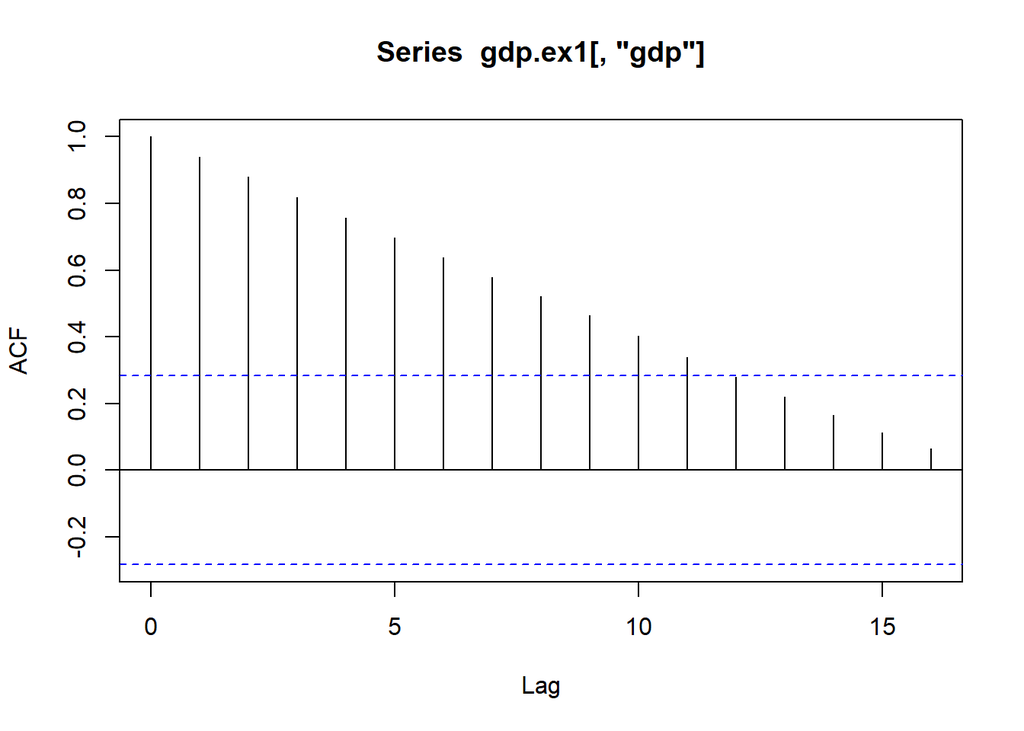

```r
library(wbstats)
gdp <- wb(country="all",
          indicator="NY.GDP.PCAP.CD",
          startdate=1970,
          enddate=2019) %>% select(iso3c, date, value) %>%  arrange(date)
oil <- wb(country="all",
          indicator="NY.GDP.PETR.RT.ZS",
          startdate=1970,
          enddate=2019) %>% select(iso3c, date, value) %>%  arrange(date)
pop <- wb(country="all",
          indicator="SP.POP.TOTL",
          startdate=1970,
          enddate=2019) %>% select(iso3c, date, value) %>%  arrange(date)

wbdat <- gdp %>% right_join(oil, by=c("iso3c","date")) %>% right_join(pop, by=c("iso3c","date"))
colnames(wbdat)[3:5] <- c("gdp","oilrents","pop")


library(forecast)
countries <- wbdat$iso3c %>% unique()
ex1 <- wbdat  %>% filter(iso3c == "USA")
ex1$date <- as.numeric(ex1$date)
ex1 <- ex1 %>% arrange(date)
gdp.ex1 <- ts(ex1, start=ex1$date[1], end=ex1$date[nrow(ex1)], frequency=1)
gdp.ex1 <- na.omit(gdp.ex1)
acf(gdp.ex1[,"gdp"]) #ACf for AR
```

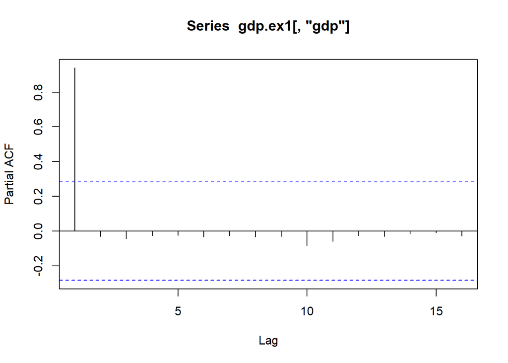

```r
pacf(gdp.ex1[,"gdp"]) #PACF for MA'
```

```r
#arima.obj <- arima(growth.ex1[,"growth"], order=c(1,0,0))
```

You should also see if the same picture emerges for other countries. Plot the ACFs and PACFs for up to 10 countries of your choice. See if ARIMA(1,0,1) is appropriate for all cases:

```r
for(i in 1:10){
  d <- wbdat %>% filter(iso3c == countries[i])
  d$date <- as.numeric(d$date)
  d <- d %>% arrange(date)
  ts.dat <- ts(d, start=1970, end=2019, frequency=1) %>% na.omit()
  acf(ts.dat[,"gdp"])
}

for(i in 1:10){
  d <- wbdat %>% filter(iso3c == countries[i])
  d$date <- as.numeric(d$date)
  d <- d %>% arrange(date)
  ts.dat <- ts(d, start=1970, end=2019, frequency=1) %>% na.omit()
  pacf(ts.dat[,"gdp"])
}
```

Let’s go with our speculation and fit an ARIMA(1,0,1) model on the US data. Then check the residuals by calling `checkresiduals()` to see if there are still spikes in the ACF. If the model fits well, then there should be no spikes in the ACF. If not, you should adjust the parameters in the ARIMA model.

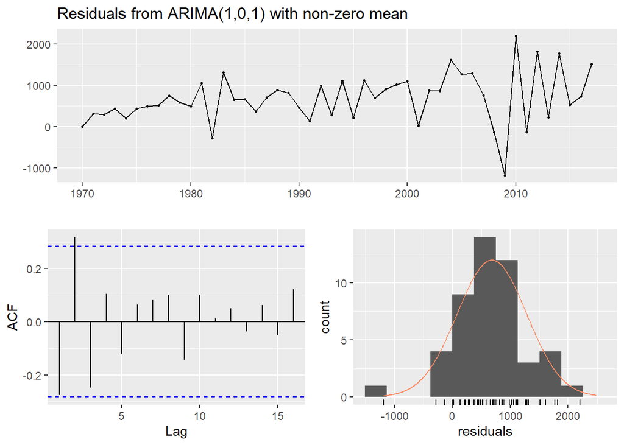

```
##
##  Ljung-Box test
##
## data:  Residuals from ARIMA(1,0,1) with non-zero mean
## Q* = 17.003, df = 7, p-value = 0.01737
##
## Model df: 3.   Total lags used: 10
```

```r
library(forecast)
arima101 <- arima(gdp.ex1[,"gdp"], order = c(1,0,1), method="ML")
checkresiduals(arima101)
```

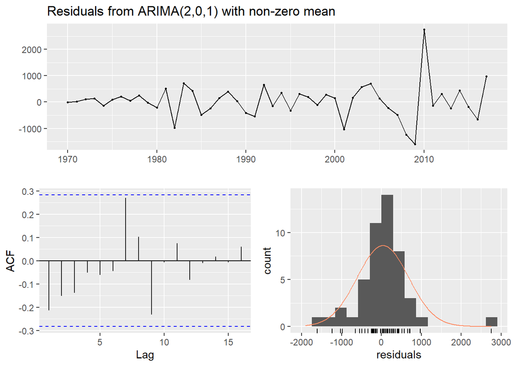

```
##
##  Ljung-Box test
##
## data:  Residuals from ARIMA(2,0,1) with non-zero mean
## Q* = 13.227, df = 6, p-value = 0.03958
##
## Model df: 4.   Total lags used: 10
```

```r
arima201 <- arima(gdp.ex1[,"gdp"], order = c(2,0,1), method="ML")
checkresiduals(arima201)
```

To speed things up, you can use the `auto.arima()` function from the `forecast` package to help you find the ARIMA parameters automatically. It computes a series of plausible ARIMA parameters and return the best ARIMA model with the lowest information criteria scores.

It is intuitive that not all time series follow the same pattern, so you should check if this applies to other countries as well. Plot the auto.arima results for 10 countries of your choice and see what are the best parameters to use:

```r
for(i in 1:10){
  d <- wbdat %>% filter(iso3c == countries[i])
  d$date <- as.numeric(d$date)
  d <- d %>% arrange(date)
  ts.dat <- ts(d, start=1970, end=2019, frequency=1) %>% na.omit()
  auto.arima(ts.dat[,"gdp"]) %>% checkresiduals()
}
```

We are now ready to fit the model via `brms`. Regress GDP on Oil Rents and Logged Population levels. Specify the correlation structure using the `autocor` argument. It takes a formula for the autocorrelation structure. In our case, we will be using `arma(p=2, q=2)` since we need an ARMA(2,2) model (ignoring integration for now!):

```r
library(brms)

wb.brm <- brm(gdp ~ oilrents + log(pop),
          autocor= ~ brms::arma(time=date, gr=iso3c, p=2, q=2, cov=T),
          family=gaussian(), data=na.omit(wbdat),
          prior = c(
    prior(normal(0,10), "b"),
    prior(normal(0,50), "Intercept")),
              chains=2, cores=5, iter=1000, warmup=100)
```

In addition, we can plot the posterior distribution of the $\beta$s by calling `plot()`:

```r
summary(wb.brm)
```

```
##  Family: gaussian
##   Links: mu = identity; sigma = identity
## Formula: gdp ~ oilrents + log(pop)
##          autocor ~ tructure(list(), class = "formula", .Environment = <environment>)
##    Data: na.omit(wbdat) (Number of observations: 9567)
## Samples: 2 chains, each with iter = 1000; warmup = 100; thin = 1;
##          total post-warmup samples = 1800
##
## Population-Level Effects:
##           Estimate Est.Error l-95% CI u-95% CI Rhat Bulk_ESS Tail_ESS
## Intercept   972.35    228.47   476.42  1378.21 1.33        5       19
## oilrents     -0.66      8.77   -16.30    17.07 1.01      137      228
## logpop      -21.77      9.75   -40.80    -2.70 1.02       82      187
##
## Family Specific Parameters:
##       Estimate Est.Error l-95% CI u-95% CI Rhat Bulk_ESS Tail_ESS
## sigma 14732.48    126.01 14501.30 14988.32 1.13       10       40
##
## Samples were drawn using sampling(NUTS). For each parameter, Bulk_ESS
## and Tail_ESS are effective sample size measures, and Rhat is the potential
## scale reduction factor on split chains (at convergence, Rhat = 1).
```

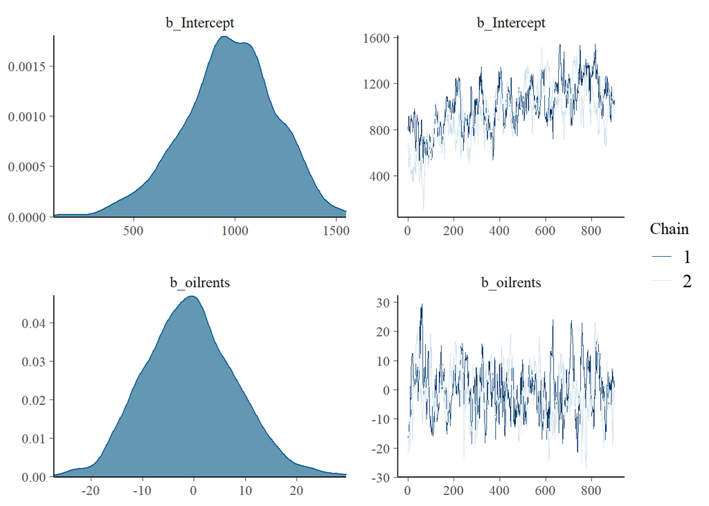

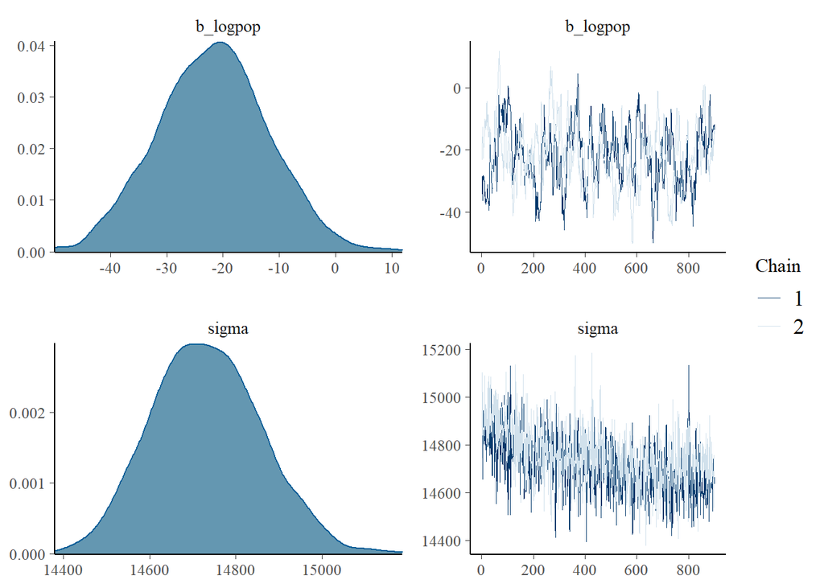

```r
plot(wb.brm, N=2, ask=F)
```

These essentially visualize what `summary()` has already told us: It seems like oil rents do not matter for GDP growth.

You may also use `conditional_effects()` to visualize the conditional effects easily.

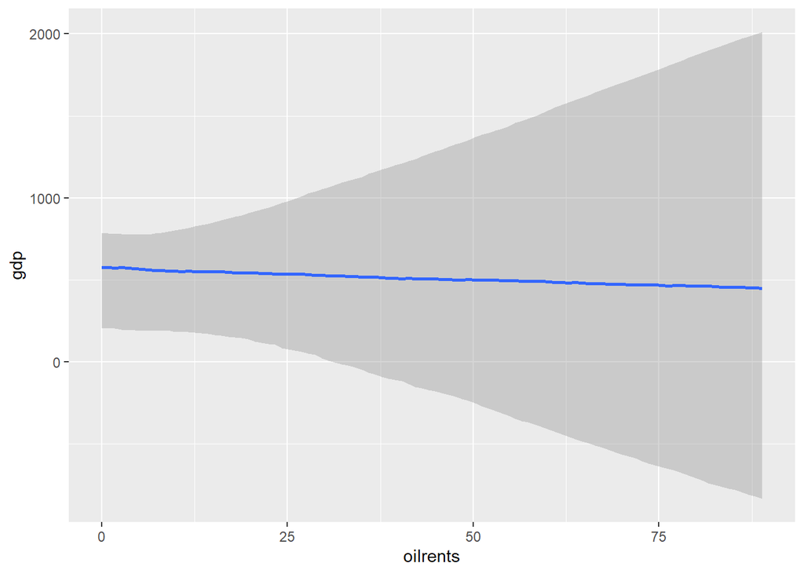

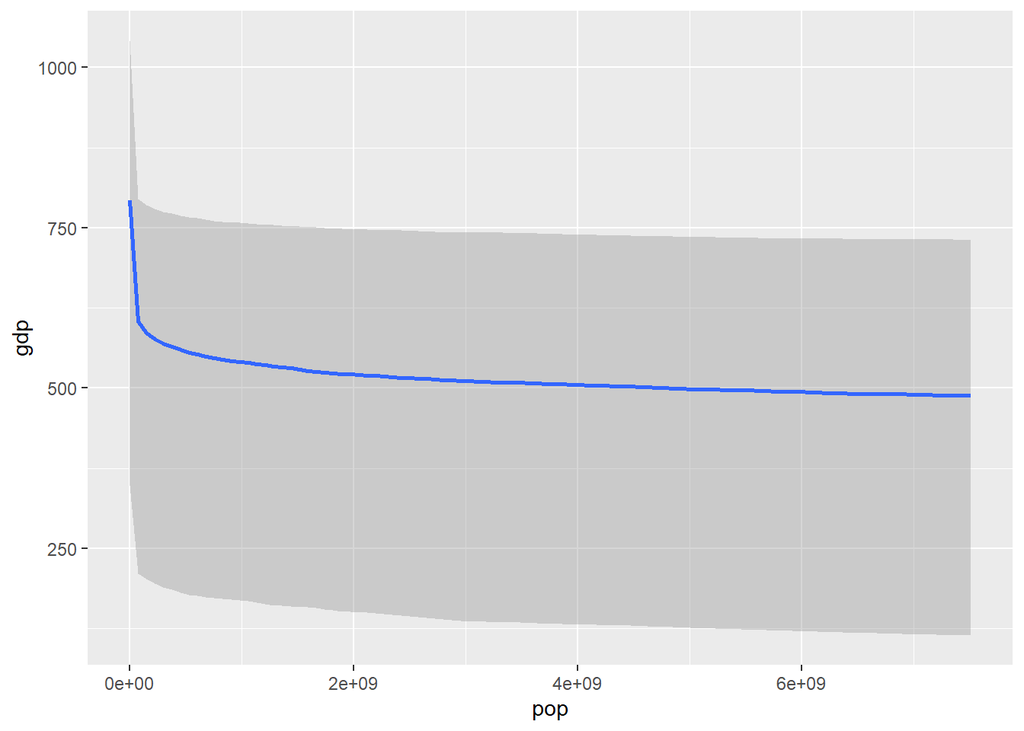

```r
conditional_effects(wb.brm)
```

Now note that for time purposes, I have only let the model sample 1000 times from the posterior. This is far from sufficient! Below you should play around with different ARMA settings, as well as improving the number of draws from the posterior and the number of burn-in steps (e.g. 4000 is a good start). This would help reach model convergence since the MCMC algorithm needs to run for a while to achieve stationarity in the Markov Chain (and thus model convergence).

# Reference

Alvarez, R Michael, Geoffrey Garrett, and Peter Lange. 1991. “Government Partisanship, Labor Organization, and Macroeconomic Performance.” *American Political Science Review* 85 (2): 539–56.

Bailey, Delia, and Jonathan N. Katz. 2011. “Implementing Panel-Corrected Standard Errors in R: The Pcse Package.” *Journal of Statistical Software*.

Beck, Nathaniel, Jonathan N. Katz, R. Michael Alvarez, Geoffrey Garrett, and Peter Lange. 1993. “Government Partisanship, Labor Organization, and Macroeconomic Performance: A Corrigendum.” *American Political Science Review* 87 (4): 943–48.